# R Notebook

## Node placement can make a big difference in how a network is perceived

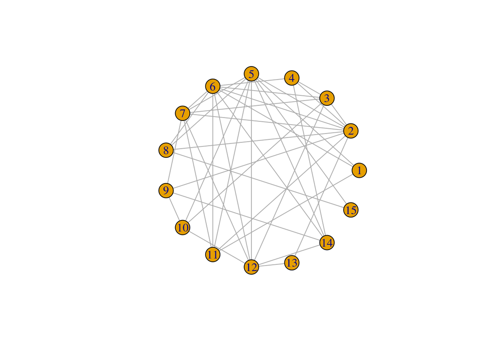

```r
# Each of these shows a different layout of the same random graph; note how different the conclusions we might draw are.
G = random.graph.game(15, .4)
plot(G, layout = layout_in_circle(G))
```

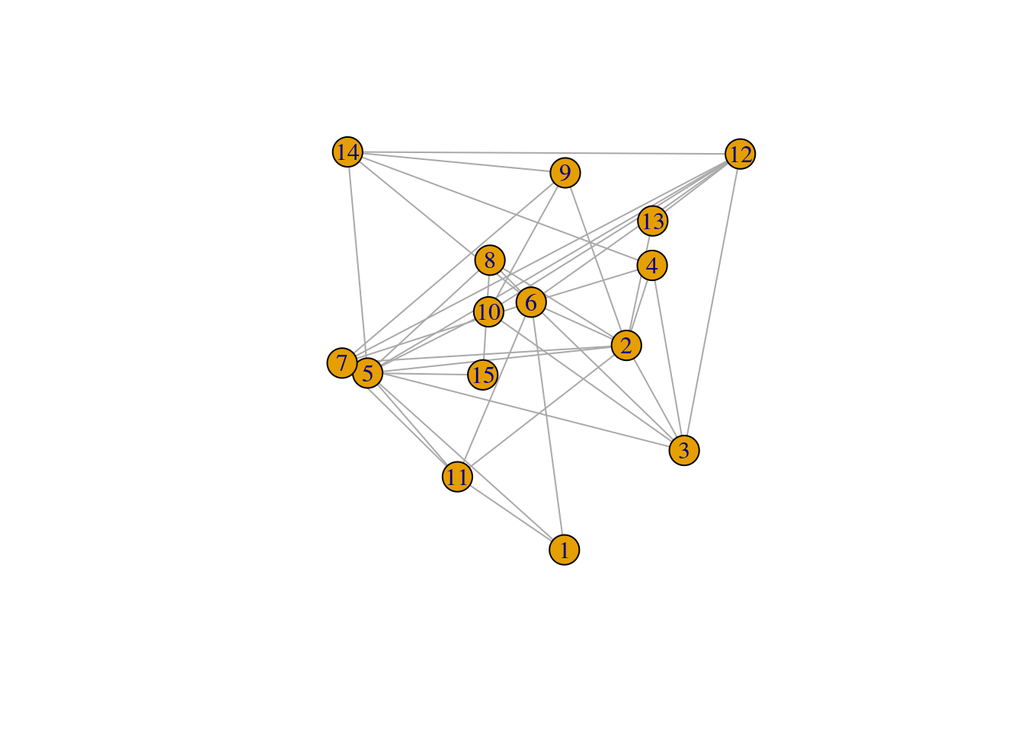

```r
plot(G, layout = layout_randomly)
```

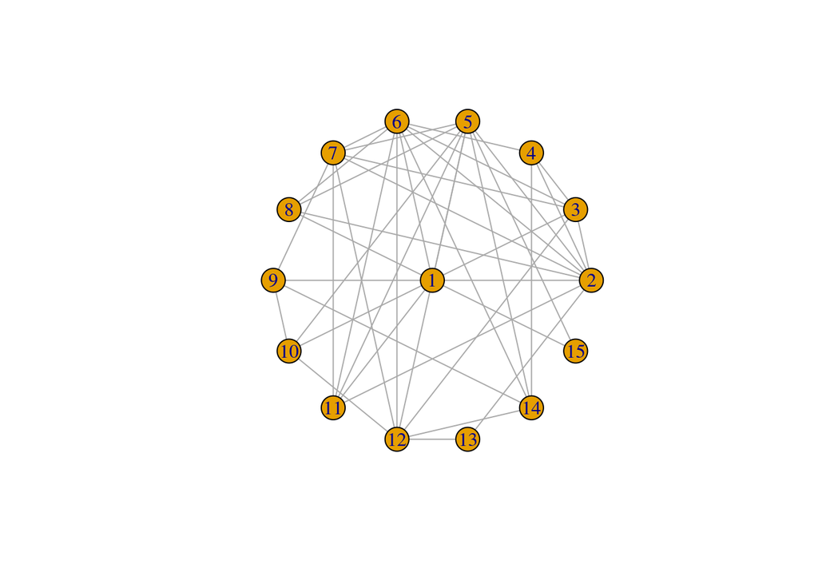

```r
plot(G, layout = layout_as_star)
```

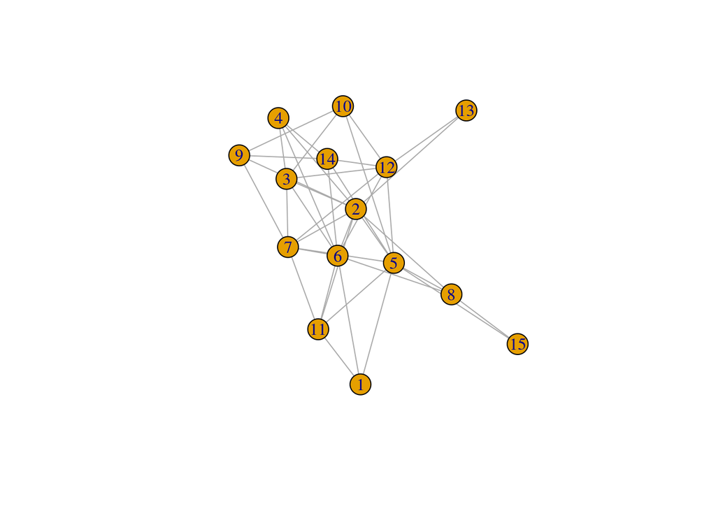

```r
plot(G)
```

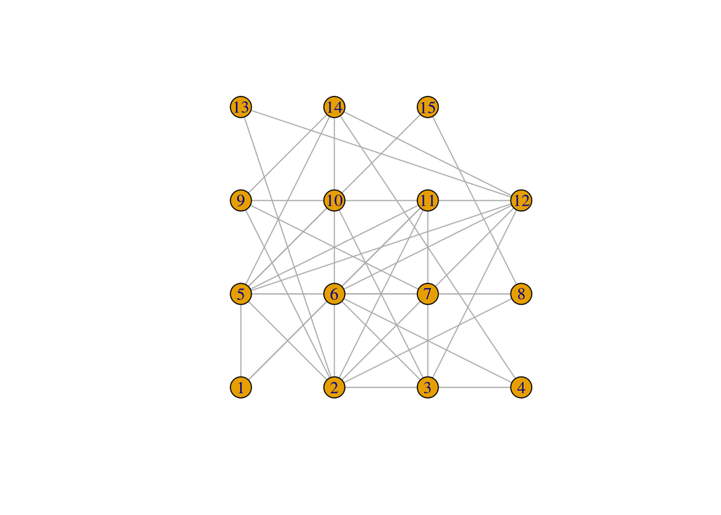

```r
plot(G, layout = layout_on_grid)
```

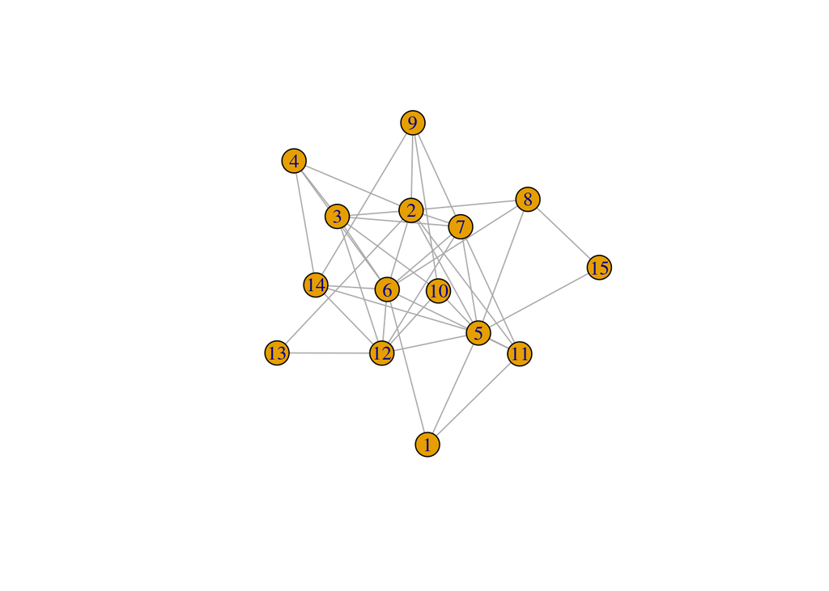

```r
plot(G, layout = layout_with_lgl)
```

# School Data

Now it’s your turn. We are going to have a visualization competition, to see who can make the most interesting and insightful visualizations of a new dataset.

The data comes from a Dutch school class in 2003, and is described [at this website](http://www.stats.ox.ac.uk/~snijders/siena/tutorial2010_data.htm).

In order to make things easier, I’ve changed this messy data of multiple matrices into an igraph object for you. You can see how I did that [here](https://github.com/jdfoote/Communication-and-Social-Networks/blob/master/activities/knecht_school_data.r).

So, what you’ll need to do first is load the data.

```r
load(url('https://github.com/jdfoote/Communication-and-Social-Networks/raw/master/activities/school_graph.Rdata'))
```

If this doesn’t work, then download the file from that URL, and do `load('/path/to/file')`

There are two different graphs that get loaded. `G` is the full graph, and includes two kinds of edges: whether A and B are friends, and whether they went to the same primary school.

```r
# This shows all of the edges and attributes about them
E(G)[[]]
```

```
## + 203/203 edges from a403a0d (vertex names):
##     tail head tid hid           type
## 1     V1   V3   1   2     friendship
## 2     V1  V12   1  11     friendship
## 3     V3   V1   2   1     friendship
## 4     V3   V2   2  26     friendship
## 5     V3   V6   2   5     friendship
## 6     V3   V7   2   6     friendship
## 7     V3   V8   2   7     friendship
## 8     V3  V10   2   9     friendship
## 9     V3  V12   2  11     friendship
## 10    V3  V15   2  14     friendship
## 11    V4  V18   3  17     friendship
## 12    V4  V23   3  22     friendship
## 13    V5  V14   4  13     friendship
```

[output cut: 190 more lines]

The `friend_net` igraph object just includes friendship edges. I created it by doing the following:

```r
# This makes a "subgraph" by just getting the edges with the type 'friendship'
friend_net = subgraph.edges(G, E(G)[E(G)$type=='friendship'])
```

Both of these graphs include lots of data about the people in them. You can view the attributes of a vertex like this:

```r
V(friend_net)[[]]
```

```
## + 26/26 vertices, named, from 2481682:
##    name delinquency alcohol_use sex age ethnicity religion
## 1    V1           2           4   F  12         1        2
## 2    V3          NA           2   F  12         1        2
## 3    V4           2           1   F  12         2        3
## 4    V5           2           1   M  12         1        2
## 5    V6           1           1   M  12         1        2
## 6    V7           1           1   F  12         1       NA
## 7    V8           2           3   F  12         1        2
## 8    V9           1           1   F  13         1        2
## 9   V10           2           3   F  12         1        2
## 10  V11           2           2   F  12         1        1
## 11  V12           2           2   F  12         1        2
## 12  V13           1           5   F  12         2        3
## 13  V14           2           3   M  13         1        2
## 14  V15           2           3   M  12         1        2
## 15  V16           1           1   F  11         1        1
## 16  V17           1          NA   M  12         1       NA
## 17  V18           1           1   F  13         1        1
## 18  V19           1           1   M  12         1        2
## 19  V20          NA          NA   F  13         1       NA
## 20  V21           3           2   F  12         1        2
## 21  V22           2          NA   F  12        NA       NA
## 22  V23           1           1   F  12         1        3
## 23  V24           1          NA   M  12         1        2
## 24  V25           1           1   F  11         1        1
## 25  V26           2           1   M  12         1        2
## 26   V2           2           2   M  12         1        2
```

Descriptions of what each measure means are at the [site the data came from](http://www.stats.ox.ac.uk/~snijders/siena/tutorial2010_data.htm).

Basically, it includes information about alcohol use, gender, age, ethnicity (whether Dutch or not), and religion.

## The Goal

Your assignment during class is to come up with something interesting that a network visualization of this data could tell us, and a drawing (on paper) of what you want it to look like.

## Homework

Your homework (due the Tuesday after Spring Break) is to create a beautiful, insightful visualization of this network that helps us to see something that might not otherwise be apparent.